# 기간별에 따른 주제 변화, 야놀자 중심으로

2022-11-02

> 빅카인즈 키워드 검색을 통해 ‘야놀자’와 ’여기어때’ 기업에 대한 기사를 분석함

> 분석 순서로는 **공변인 토픽 개수 선정, 월별,년도별 주제 변화도** 순으로 분석했다.

### 1. 분석에 앞선 기본적인 준비

##### *1) 패키지 설치 및 불러오기*

**패키지 불러오기**

##### *2) 파일 경로 설정*

**파일경로 설정**

```r
setwd("C:/Users/YH JUNG/Documents/R/GIT/residence/data")

getwd()
```

```
## [1] "C:/Users/YH JUNG/Documents/R/GIT/residence/data"
```

### 2. 주제모형

> 모형 구축을 위해 기준점이 되는 자료 열 “press”, “cat” 등을 새롭게 불러와 자료를 수집하고

> 수집한 기사의 중복 기사를 삭제하고 기사별 열 번호를 기입하여 분석에 용의하게 정제했다.

> 다양한 언론사를 야당지와 여당지로 추가 분류하였고 속하지 않은 언론사는 여당지로 분류하였다.

**자료 정제**

##### 1) 모델링을 위한 자료 수집

기간을 세분화하기 위해 lubridate 패키지를 사용하여 일자를 세분화하여 추가했다.

##### 2) 자료 정제

**야놀자 자료 정제**

```r
yanolja_sub2 <- yanolja_sub %>%

distinct(제목, .keep_all = T) %>%

mutate(ID = factor(row_number())) %>%

mutate(date = ymd(일자)) %>%

mutate(year = year(date)) %>%

mutate(month = month(date)) %>%

mutate(day = day(date)) %>%

unite(제목, 본문, col = "text", sep = " ") %>%

mutate(text = str_squish(text)) %>%

mutate(press = case_when(

언론사 == "조선일보" ~ "야당지",

언론사 == "중앙일보" ~ "야당지",

언론사 == "동앙일보" ~ "야당지",

언론사 == "국민일보" ~ "야당지",

언론사 == "문화일보" ~ "야당지",

언론사 == "한국경제" ~ "야당지",

언론사 == "경향신문" ~ "여당지",

TRUE ~ "여당지") ) %>%

separate(cat, sep = ">", into = c("cat", "cat2")) %>%

select(-cat2) %>%

mutate(catSoc = case_when( cat == "경제" ~ "경제면",
                           cat == "문화" ~ "경제면",
                           TRUE ~ "비경제면") )

#주제별 갯수
yanolja_sub2 %>% count(cat, sort = T)
```

```
## # A tibble: 9 x 2
##   cat         n
##   <chr>   <int>
## 1 경제     2753
## 2 IT_과학  1488
## 3 지역      532
## 4 문화      464
## 5 정치      172
## 6 미분류    134
## 7 사회      106
## 8 국제       47
## 9 스포츠     15
```

##### 3) 토큰화

**야놀자 토큰화**

```r
fullchar_v <- "ㆍ|ㅣ|‘|’|“|”|○|●|◎|◇|◆|□|■|△|▲|▽|▼|〓|◁|◀|▷|▶|♤|♠|♡|♥|♧|♣|⊙|◈|▣"


#야놀자 토큰화
yanolja_S <- yanolja_sub2 %>%

mutate(키워드 = str_remove_all(키워드, "[^(\\w+|\\d+|,)]")) %>%

mutate(키워드 = str_remove_all(키워드, fullchar_v)) %>%

unnest_tokens(word, 키워드, token = "regex", pattern = ",")

#토큰화 후 데이터 결합

yanolja_C <- yanolja_S %>%

group_by(ID) %>%

summarise(text2 = str_flatten(word, " ")) %>%

ungroup() %>%

inner_join(yanolja_sub2, by = "ID")
```

##### 4) stm 말뭉치

**야놀자 stm 말뭉치 & 객체 할당**

```r
processed_yanol <- yanolja_C %>%
  textProcessor(documents = yanolja_C$text2,
                metadata = .,
                wordLengths = c(2, Inf))
```

```
## Building corpus...
## Converting to Lower Case...
## Removing punctuation...
## Removing stopwords...
## Removing numbers...
## Stemming...
## Creating Output...
```

```r
out_yanol <- prepDocuments(processed_yanol$documents,
                           processed_yanol$vocab,
                           processed_yanol$meta,
                           lower.thresh = 0)

summary(out_yanol)
```

```
##                Length Class      Mode
## documents       5711  -none-     list
## vocab          61084  -none-     character
## meta              13  data.frame list
## words.removed      0  -none-     character
## docs.removed       0  -none-     NULL
## tokens.removed     1  -none-     numeric
## wordcounts     61084  -none-     numeric
```

```r
# 모형구축을 위한 객체 저장
docs_yanol <- out_yanol$documents

vocab_yanol <- out_yanol$vocab

meta_yanol <- out_yanol$meta
```

##### 5) 공변인 분석

**야놀자 주제모형(공변인) 분석**

```r
#시스템 시간
t1 <- Sys.time()
t2 <- Sys.time()
#주제모형 구성
meta_fit_yanol_m <- stm(documents = docs_yanol,
                      vocab = vocab_yanol,
                      data = meta_yanol,
                      K = 10,
                      prevalence =~ press + s(month, 12),
                      max.em.its = 75,
                      verbose = F,
                      init.type = "Spectral",
                      seed = 37)

meta_fit_yanol_y <- stm(documents = docs_yanol,
                      vocab = vocab_yanol,
                      data = meta_yanol,
                      K = 10,
                      prevalence =~ press + s(year, 3),
                      max.em.its = 75,
                      verbose = F,
                      init.type = "Spectral",
                      seed = 37)
```

**야놀자 월별 주제 분포**

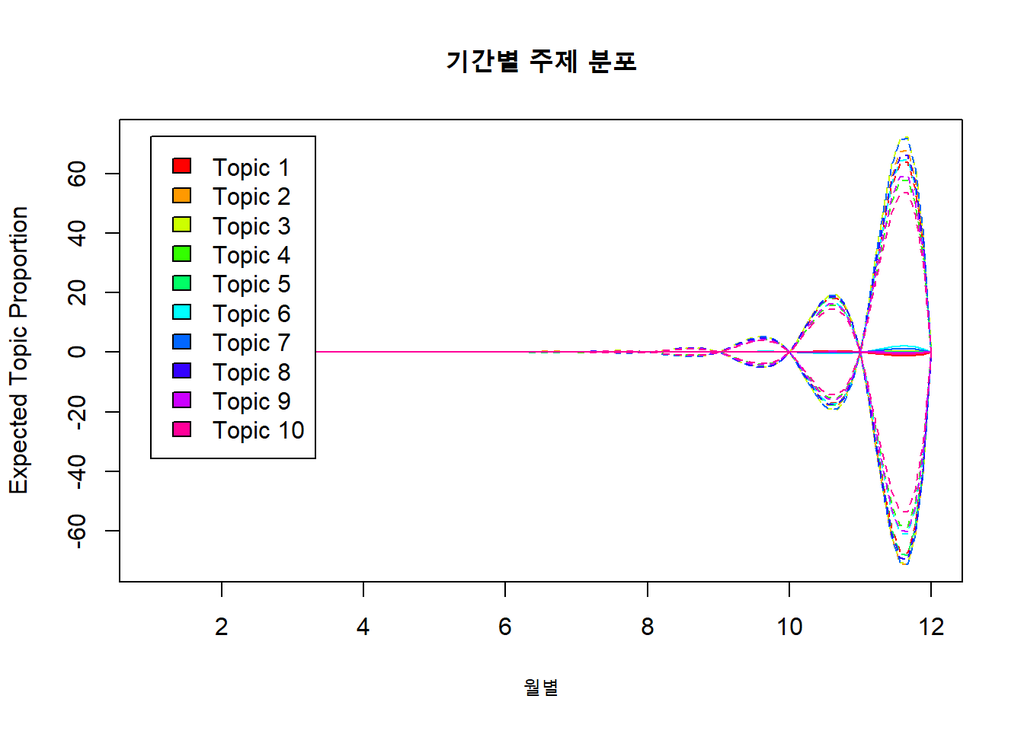

```r
prep_m <- estimateEffect(formula = 1:10 ~ press + s(month, 12),
                       stmobj = meta_fit_yanol_m,
                       metadata = out_yanol$meta,
                       uncertainty = "Global")

plot.estimateEffect(
  prep_m,
  covariate = "month",
  topics = c(1:10),
  model = meta_fit_yanol_m,
  method = "continuous", # 시간대 연속적으로 표시
  xlab = "월별",
  main = "기간별 주제 분포"
)
```

**야놀자 연도별 주제 분포**

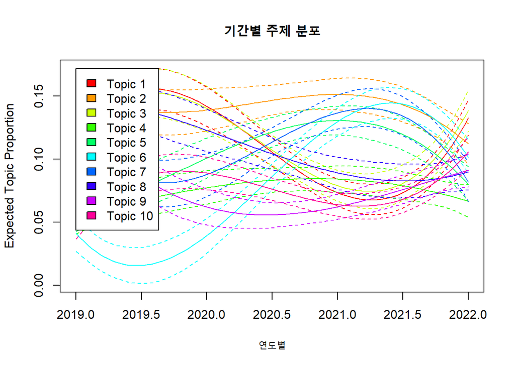

```r
prep_y <- estimateEffect(formula = 1:10 ~ press + s(year, 3),
                       stmobj = meta_fit_yanol_y,
                       metadata = out_yanol$meta,
                       uncertainty = "Global")

plot.estimateEffect(
  prep_y,
  covariate = "year",
  topics = c(1:10),
  model = meta_fit_yanol_y,
  method = "continuous", # 시간대 연속적으로 표시
  xlab = "연도별",
  main = "기간별 주제 분포"
)
```